# ECo 602 - Analysis of Environmental Data

Final Project

Ana Ivanova

Fall 2020

# Introduction

Presented below is a set of functions relating to data structure, numerical data exploration, graphical data exploration, distrbutions, and other kinds of functions as well as examples for how to utilize them! These functions wre introduced in the ECO 602 Analysis of Environmental Data and this document was produced as the final term project for the course. In the second part, I applied some of these main functions to analyze an existing data set.

# Functions 1: Data Structure Functions

## `c()`

The first fundemental function is the `c()` function which *combines* or *concatenates* arguments into a vector. A vector is defined as a 1-dimensional data structure that consists of atleast 1 element.

In order to produce a successful vector, all of the elements must be of the same *type* meaning I can’t combine character and numeric types in the same call to `c()`

Below I present two examples for creating vectors. One will use numeric data and the other will use character data:

```r
# Creating a vector with numerical data:
num_vec  = c(1, 2, 3, 4, 5, 6, 7, 8, 9, 10)

# Creating a vector with character data:
char_vec = c("strawberry", "blueberry", "raspberry")
```

In order to show the contents of a vector, I need to type the name of the vector or use the `print()` function.

```r
# Here is an example of how typing the name of one of my vectors (num_vec) prints the contents
num_vec
```

```
##  [1]  1  2  3  4  5  6  7  8  9 10
```

```r
# I can do the same thing using the print() function
print(num_vec)
```

```
##  [1]  1  2  3  4  5  6  7  8  9 10
```

## `data.frame()`

You can build a data frame from scratch by using the `data.frame` function

```r
# Building a data frame that will include character data (in quotations) and numeric data

dat_1 = data.frame(letters = c("A", "B", "C"), numbers = c(1, 2, 3))

# I can print my data frame by typing the name of the data frame

dat_1
```

```
##   letters numbers
## 1       A       1
## 2       B       2
## 3       C       3
```

You can also subset a data frame using a variety of different methods.

- If you know the name of the column, you can use $

```r
# In this example I am subsetting the column called "letters" from the dat_1 dataframe

dat_1$letters
```

```
## [1] "A" "B" "C"
```

- If I want to select certain things from columns and rows I can use the `[]` function

```r
# The rows selection will come before the comma and the column selection will come after the comma. In this example I would like to select what falls in rows 1 and 2 from column 2.

dat_1[1:2,2]
```

```
## [1] 1 2
```

- You can also subset using a specific function called `subset()` which acts as a shortcut to getting the job done

```r
# Here is an example of subsetting using the `subset()` function. I am interested in selecting all the rows where the "numbers" column has a value less than 3. In the first argument of the function I will specify the data set from which I want to subset. In the second argument, I put in the conditions and the information I need to make the selection.

subset(dat_1, subset = numbers < 3)
```

```
##   letters numbers
## 1       A       1
## 2       B       2
```

## `matrix()`

A matrix is a collection of elements that are of the same data type. Data types that exist are numeric, character and logical. These elements are arranged into a fixed number of rows and columns.

I will first show a simple example of constructing a matrix in R. For this example, I will demonstrate constructing a matrix using integers between and including 1-20 split into 5 rows. A note on the component of this function:

- `Byrow` is a function that tells R that the matrix is filled either by columns or rows. In this case, I want my matrix to be filled by rows so I will write TRUE. However, if I wanted to fill my matrix by columns I would have written FALSE.
- The function `nrow` specifies how many rows you want to use, which in this case I specified as 5.

```r
# Here is my example of constructing a matrix of the numbers 1-20 split into 5 rows

matrix(1:20, byrow = TRUE, nrow = 5)
```

```
##      [,1] [,2] [,3] [,4]
## [1,]    1    2    3    4
## [2,]    5    6    7    8
## [3,]    9   10   11   12
## [4,]   13   14   15   16
## [5,]   17   18   19   20
```

Similarly, I can construct matrices out of vectors!

```r
# For example, if I wanted to build a matrix of vector data for three different bird species. I would first create my vectors. In each vector, I want to include the species sex and color of beak.

Bird_1 = c("female", "yellow")
Bird_2 = c("male", "red")
Bird_3 = c("female", "red")

# Now I would want to combine my vectors

bird_data = c(Bird_1, Bird_2, Bird_3)

# Now I can go ahead and create my matrix which will enable me to see three rows of information (one per each species) and make many analyses. For example, I could count up how many female species I have or see if having a red beak is more common than having a yellow beak.

bird_data_matrix <- matrix(bird_data, byrow = TRUE, nrow = 3)

# To see what's in my matrix, I can print it by writing it's name

bird_data_matrix
```

```
##      [,1]     [,2]
## [1,] "female" "yellow"
## [2,] "male"   "red"
## [3,] "female" "red"
```

I can also modify my matrix to look nice by adding names to the columns and rows

```r
# For example if I want to name my columns as sex and color of beak I can use 'colnames' and to name my rows as individual bird species I can use 'rownames`. First I need to create the vectors for the headings of the columns and rows:

attribute <- c("sex", "beak color")
species_number <- c(1, 2, 3)

# Now I can name the columns and rows

colnames(bird_data_matrix) <- attribute
rownames(bird_data_matrix) <- species_number

# Now I can print out my matrix to look at it

bird_data_matrix
```

```
##   sex      beak color
## 1 "female" "yellow"
## 2 "male"   "red"
## 3 "female" "red"
```

## `length()`

The `length()` function can be used in R to get the length of a vector or set it

```r
# If I want to get the length of a vector, such as the "num_vec" vector I created earlier in my vector example I can use the `length()` function:

length(num_vec)
```

```
## [1] 10
```

```r
# If I wanted to set my vector length to be only the first 3 values instead of 10, I can also specify that using the `length()` function and printing the vector to see what I created:

length(num_vec) <- 3
num_vec
```

```
## [1] 1 2 3
```

## `nrow()`

The `nrow()` function can be used to get dimensions of a data frame. Specifically, it will tell you the number of rows present in the object you are interested in

```r
# Here is an example of how to use the function `nrow()` on a data frame that I created earlier called dat_1:

nrow(dat_1)
```

```
## [1] 3
```

## `ncol()`

The `ncol()` function can be used to get dimensions of a data frame. Specifically, it will tell you the number of columns present in the object you are interested in

```r
# Here is an example of how to use the function `ncol()` on a data frame that I created earlier called dat_1:

ncol(dat_1)
```

```
## [1] 2
```

## `dim()`

The `dim()` function in R can be used to retrieve or set the dimension of an object. Use the `dim()` function to retrieve the dimensions of an object such as a data frame, a matrix or an array. The output of the function will first report the number of rows and then the number of columns.

```r
# Here's an example of using the `dim()` function on the dat_1 data frame I created earlier:

dim(dat_1)
```

```
## [1] 3 2
```

```r
#Here's an example of using the `dim()` function on the bird_data_matrix I created earlier:

dim(bird_data_matrix)
```

```
## [1] 3 2
```

# Functions 2: Numerical Data Exploration

## `summary()`

The `summary()` function produces result summaries (of various model fitting functions).

The kind of information you receive back from using this function depends on the class of the arguments. For matrices and data frames, you will see summaries for each column.

```r
# I can use the `summary()` function on a data frame to get a summary of the characteristics of the data. Since my data frame consists of vectors with numeric and character data, I will have an output column pertaining to each:

summary(dat_1)
```

```
##    letters             numbers
##  Length:3           Min.   :1.0
##  Class :character   1st Qu.:1.5
##  Mode  :character   Median :2.0
##                     Mean   :2.0
##                     3rd Qu.:2.5
##                     Max.   :3.0
```

```r
# Here is another example of using the `summary()` function but on a matrix. The output will look slightly different from the data frame because I do not have numeric data so all the information will pertain to character data in my columns:

summary(bird_data_matrix)
```

```
##      sex             beak color
##  Length:3           Length:3
##  Class :character   Class :character
##  Mode  :character   Mode  :character
```

## `mean()`

The `mean()` function is the generic function to calculate the arithmetic mean.

- You can calculate the mean of a set of values by putting those values into a vector and taking the mean of the vector

```r
# Taking the mean of a vector

mean(c(1,2,3,4,5,6,7,8))
```

```
## [1] 4.5
```

- You can also subset a column of an existing data frame and calculate the mean of that column

```r
# A simple mean calculation for the numbers vector of the dat_1 data frame that was created earlier is presented below. To subset the number vector, I simply used the $ function introduced earlier.

mean(dat_1$numbers)
```

```
## [1] 2
```

## `sd()`

The `sd()` function can be used to compute the standard deviation of the values in the object you designate.

```r
# An example of calculating the standard deviation on the numbers vector in the dat_1 data frame

sd(dat_1$numbers)
```

```
## [1] 1
```

# Functions 3: Graphical Data Exploration

## `plot()`

I can use `plot()` to create a scatter plot

```r
# First I will load a data set to work with. Every user has access to the iris data set which can be obtained using `data()`

data(iris)

# We can look at a quick preview of what's in our data set by using the `head()` function to determine which columns we want to plot

head(iris)
```

```
##   Sepal.Length Sepal.Width Petal.Length Petal.Width Species
## 1          5.1         3.5          1.4         0.2  setosa
## 2          4.9         3.0          1.4         0.2  setosa
## 3          4.7         3.2          1.3         0.2  setosa
## 4          4.6         3.1          1.5         0.2  setosa
## 5          5.0         3.6          1.4         0.2  setosa
## 6          5.4         3.9          1.7         0.4  setosa
```

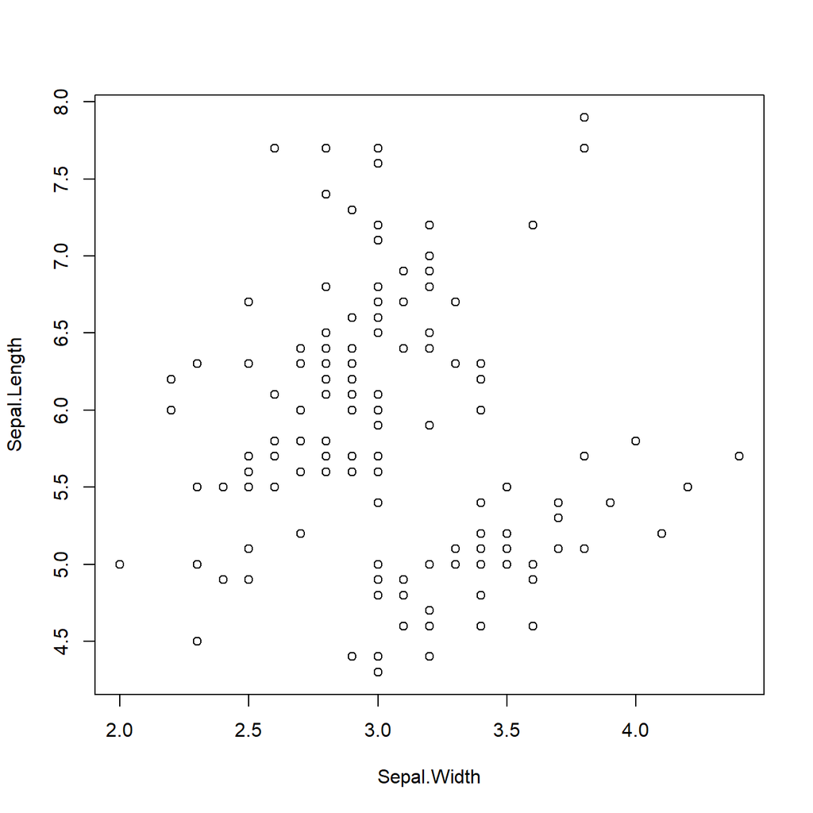

```r
# Now I can create a basic scatter plot using formula notation to plot sepal length versus sepal width and identify patterns:

plot(Sepal.Length ~ Sepal.Width, data = iris)
```

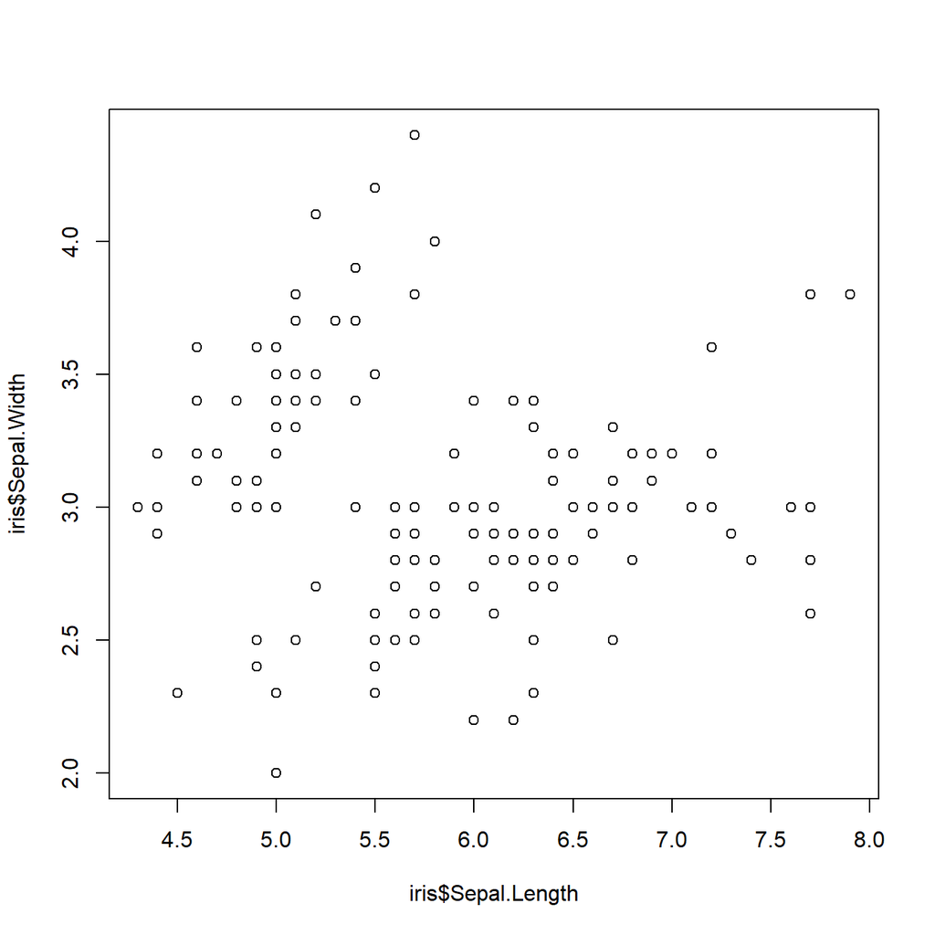

```r
# An alternative way to create the scatter plot includes subsetting from the data set

plot(x=iris$Sepal.Length, y=iris$Sepal.Width)
```

I can also customize my scatter plot to contain a variety of additional features

- I can specify the color of my points using the `col =` argument

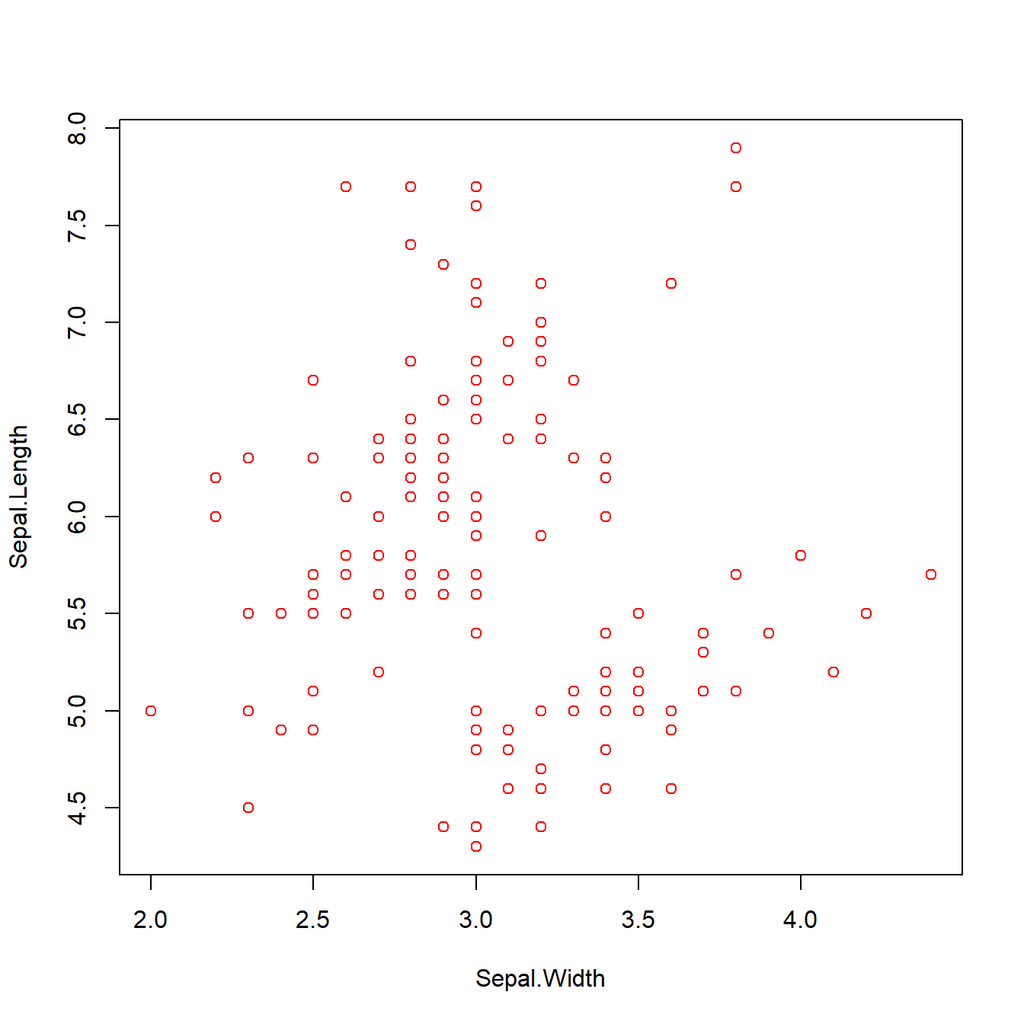

```r
# Specifying the color of points to red

plot(Sepal.Length ~ Sepal.Width, data = iris, col = "red")
```

- I can specify the symbol type for my plot using the `pch =` argument. You can write in any number between 1 and 25. What each number stands for can be found online on the R website. As an example I will include a couple symbol types below.

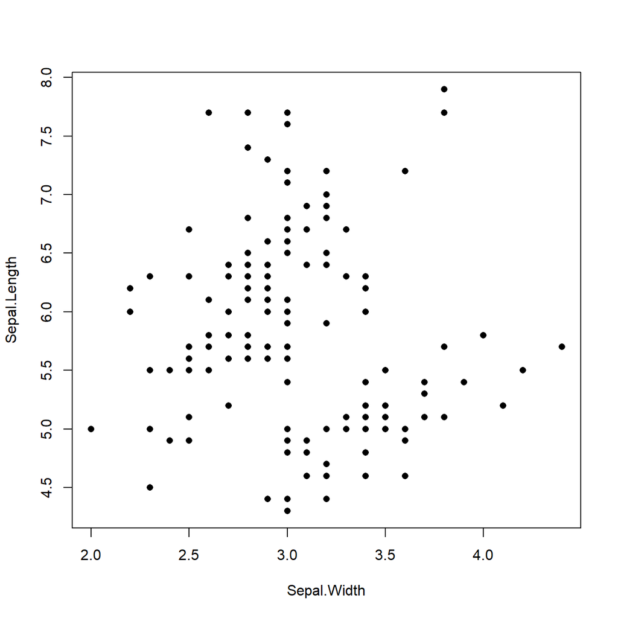

```r
#  If I want to use filled in circles as my symbol

plot(Sepal.Length ~ Sepal.Width, data = iris, pch = 16)
```

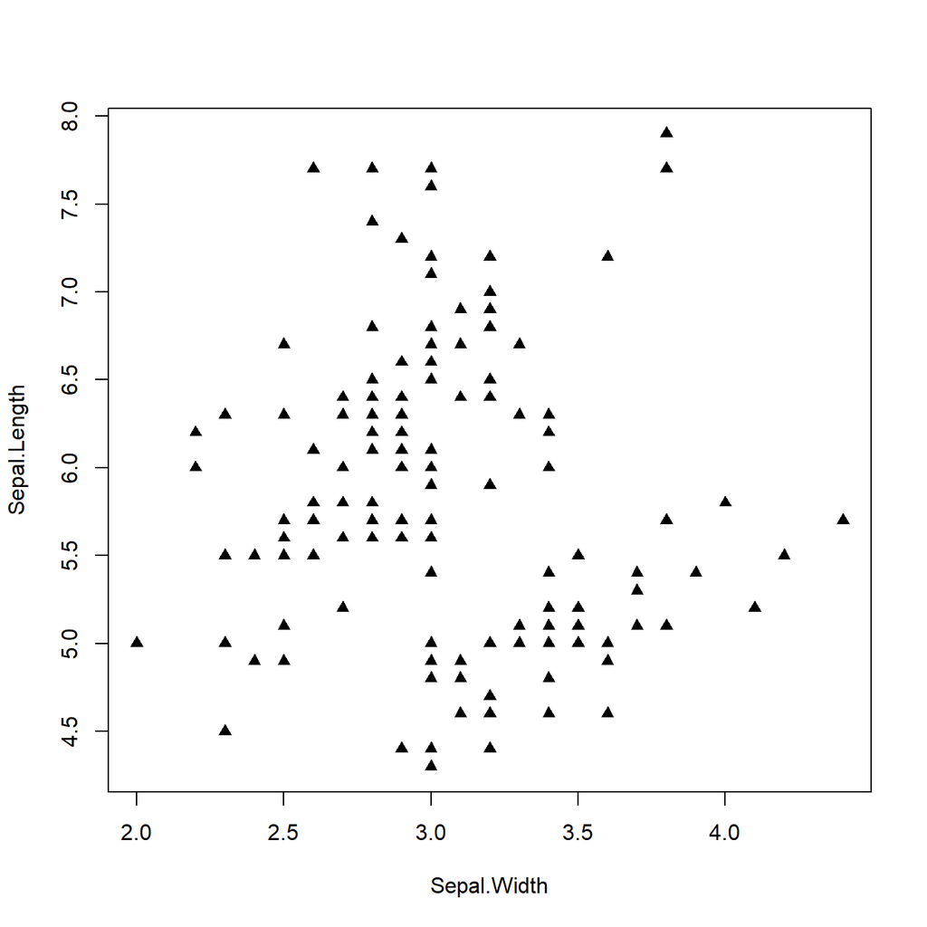

```r
# If I want to use filled in triangles as my symbol

plot(Sepal.Length ~ Sepal.Width, data = iris, pch = 17)
```

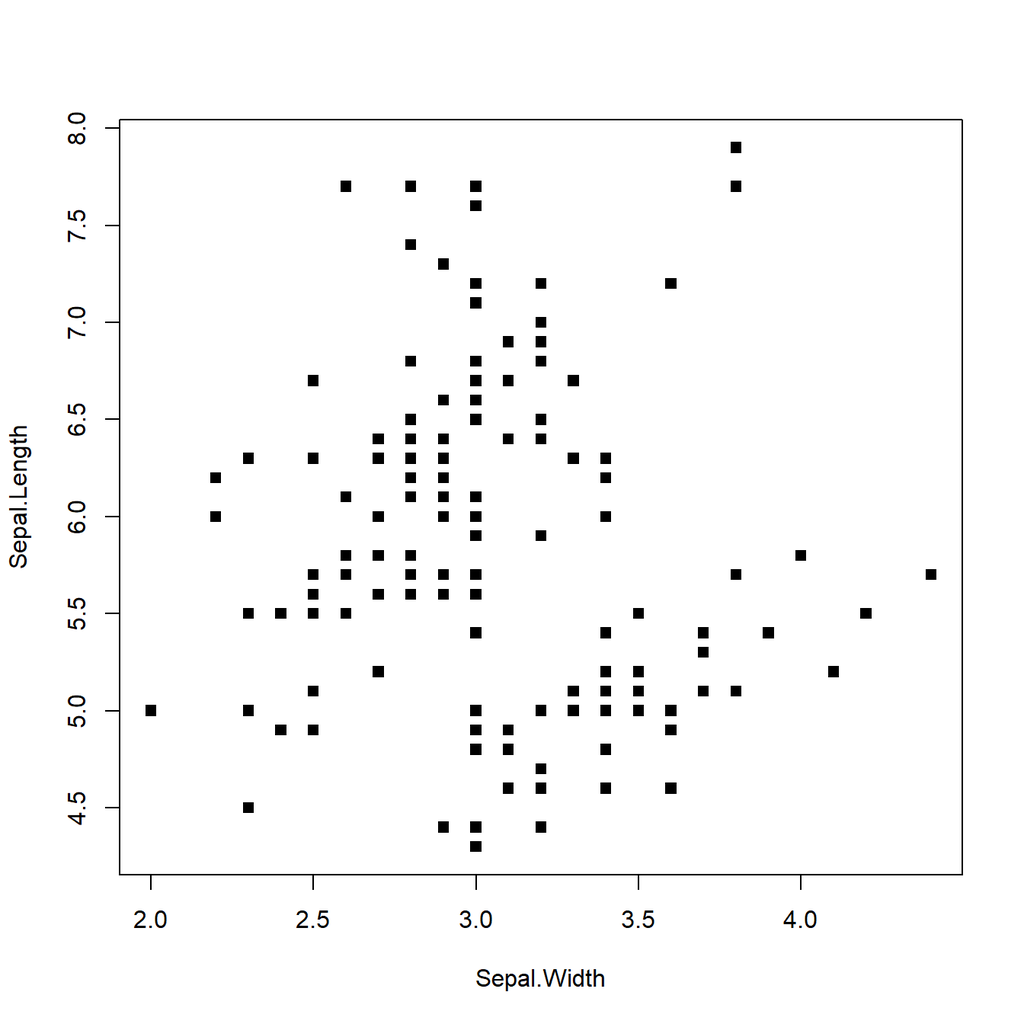

```r
# If I want to use filled in squares as my symbol

plot(Sepal.Length ~ Sepal.Width, data = iris, pch = 15)
```

- I can add a title for my plot using the `main =` argument

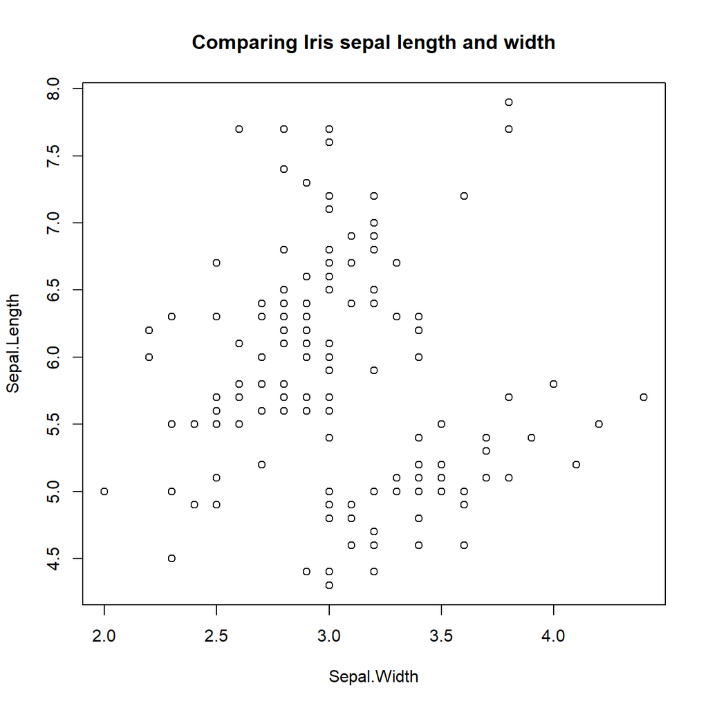

```r
# Adding a main title for the plot

plot(Sepal.Length ~ Sepal.Width, data = iris, main = "Comparing Iris sepal length and width")
```

- I can add a label for my x-axis using the `xlab =` argument

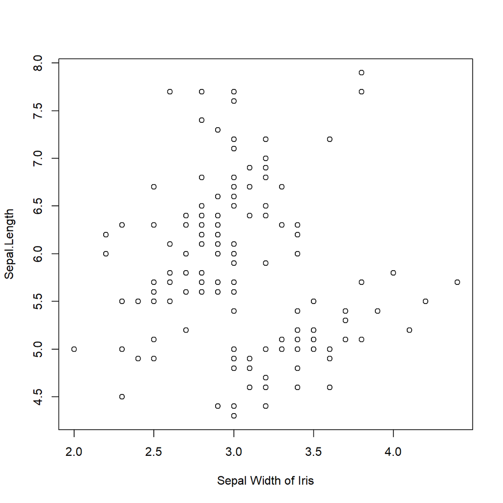

```r
# Adding an x-axis label

plot(Sepal.Length ~ Sepal.Width, data = iris, xlab = "Sepal Width of Iris")
```

- I can add a label for my y axis using the `ylab =` argument

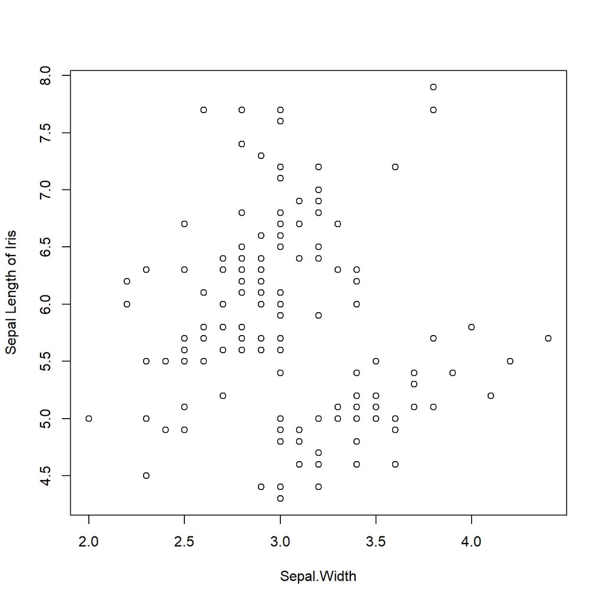

```r
# Adding a y-axis label

plot(Sepal.Length ~ Sepal.Width, data = iris, ylab = "Sepal Length of Iris")
```

- I can also specify the magnification of my points/symbols or also my labels using the `cex =` argument

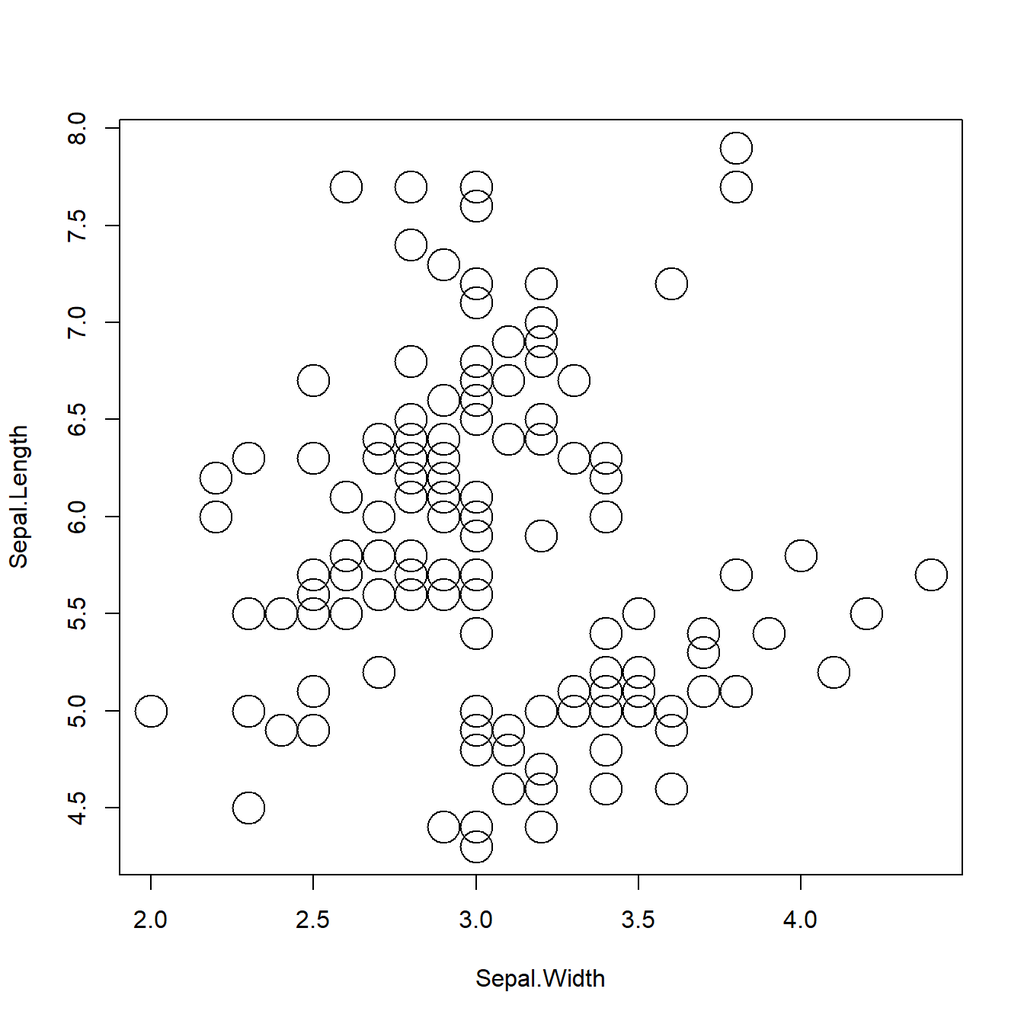

```r
# Magnifying the size of my points by 3

plot(Sepal.Length ~ Sepal.Width, data = iris, cex = 3)
```

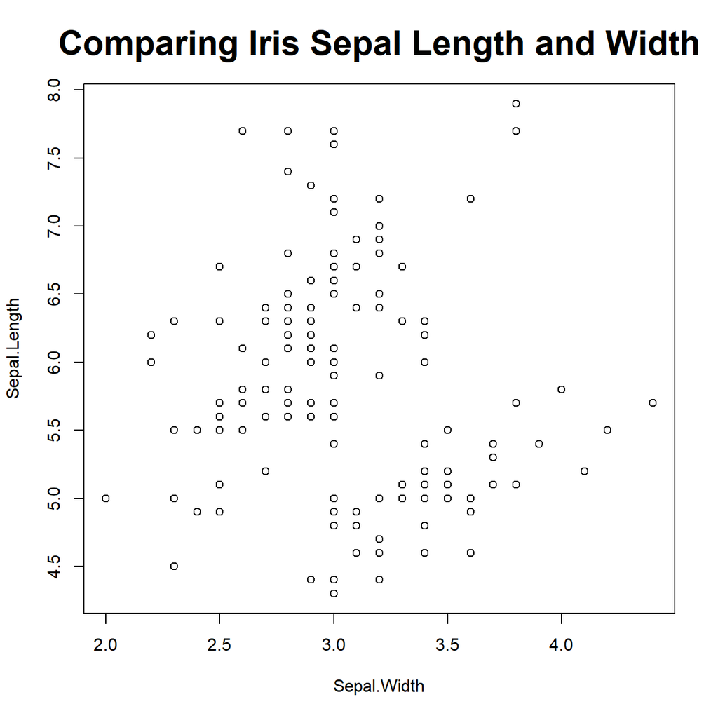

```r
# Magnifying the size of my main title by 2 using the `cex.main =` argument

plot(Sepal.Length ~ Sepal.Width, data = iris, main = "Comparing Iris Sepal Length and Width", cex.main = 2)
```

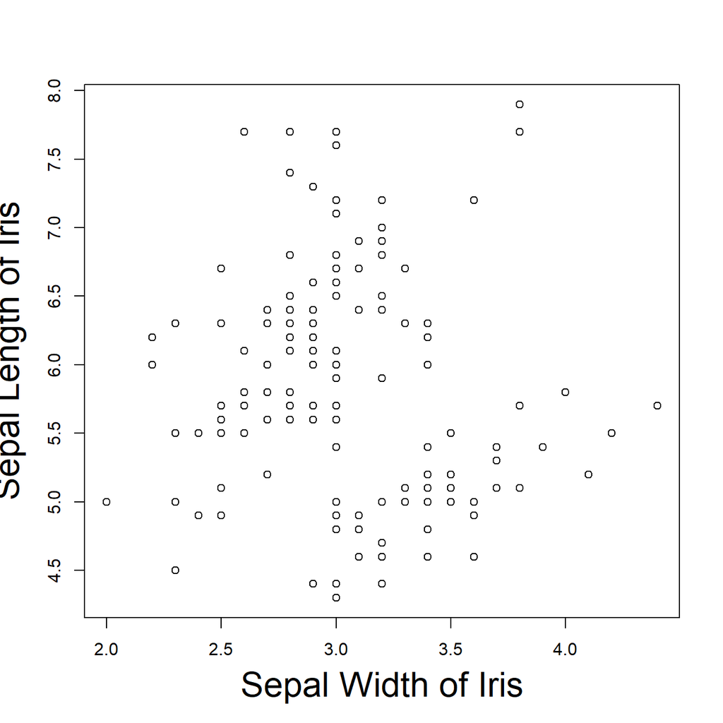

```r
# Magnifying the size of my axis labels by 2

plot(Sepal.Length ~ Sepal.Width, data = iris, xlab = "Sepal Width of Iris", ylab = "Sepal Length of Iris", cex.lab = 2)
```

- I can also establish a limit for my x-axis using the `xlim =` argument

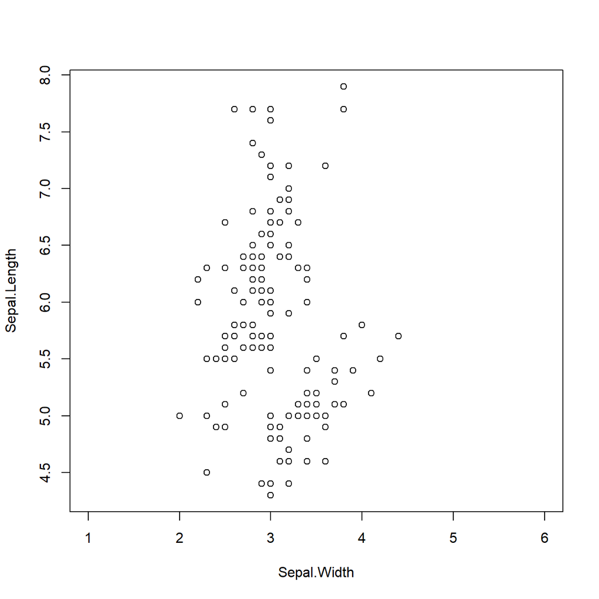

```r
# Adding a limit for the x axis by specifying a range such as 1 to 6

plot(Sepal.Length ~ Sepal.Width, data = iris, xlim = range(1:6))
```

- I can establish a limit for my y axis using the `ylim =` argument

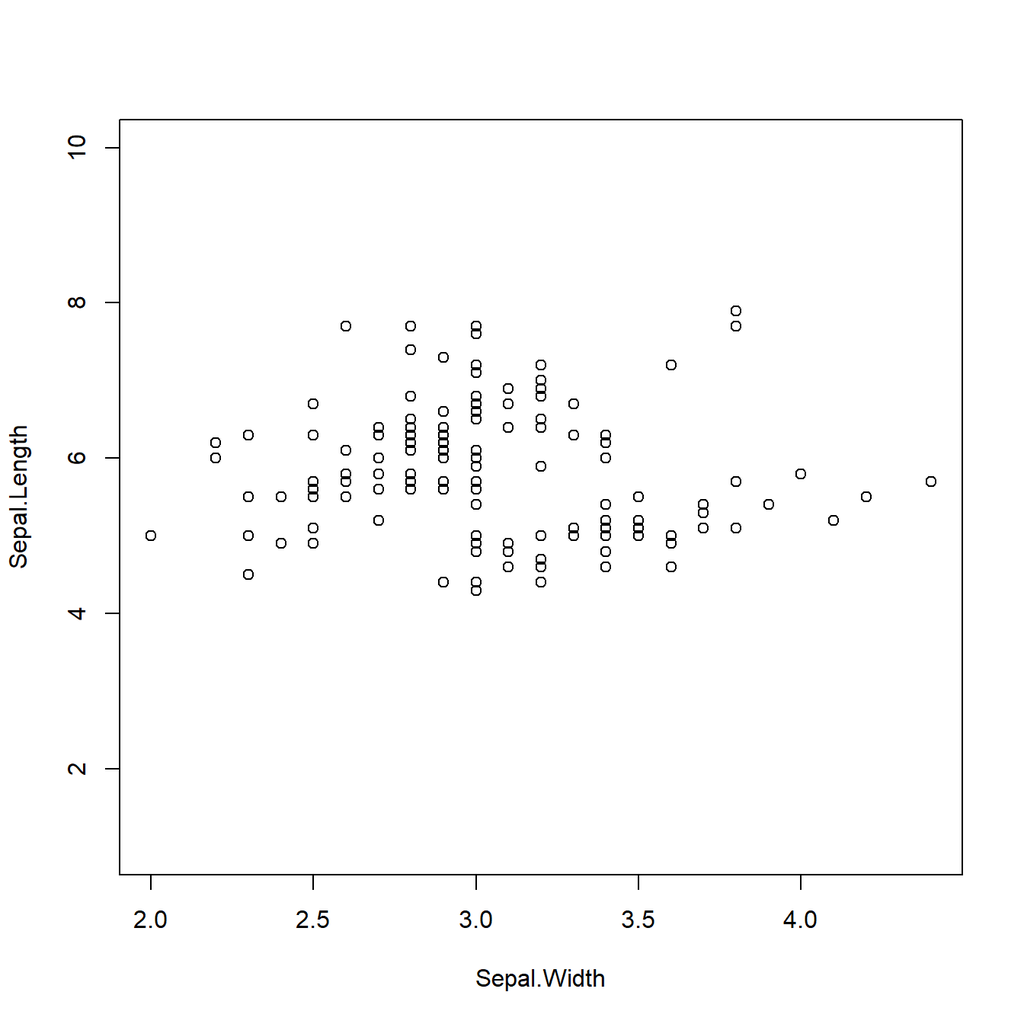

```r
# Adding a limit for the y axis by specifying a range such as 1 to 10

plot(Sepal.Length ~ Sepal.Width, data = iris, ylim = range(1:10))
```

## `boxplot()`

I can use boxplots to quickly visualize my data. In R I can make a simple boxplot using the `boxplot()` function

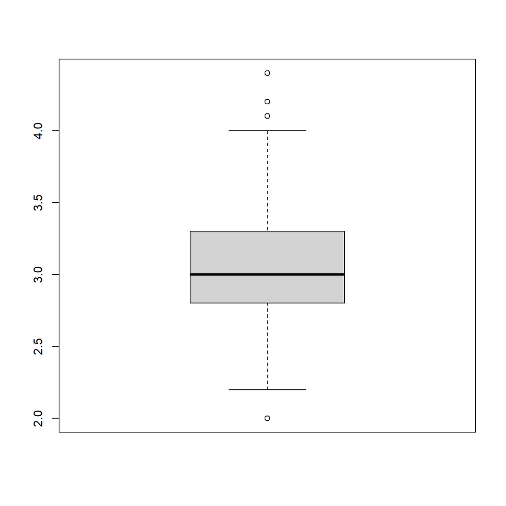

```r
# Creating a boxplot of the sepal width of the iris data. I can do that by subsetting the iris data using the `$` symbol.

boxplot(iris$Sepal.Width)
```

I can also create a conditional boxplot conditioned by some categorical variable

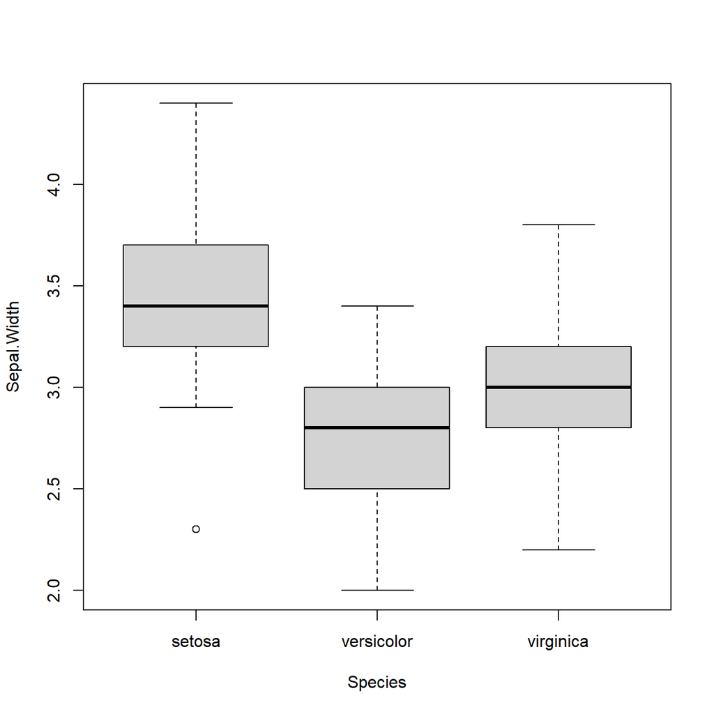

```r
# Creating a conditional boxplot using the categorical variable species. This enables me to see sepal width of iris plants conditioned by the specific species.

boxplot(Sepal.Width ~ Species, data = iris)
```

## `hist()`

I can create a histogram of data I am interested by using the `hist()` function in R

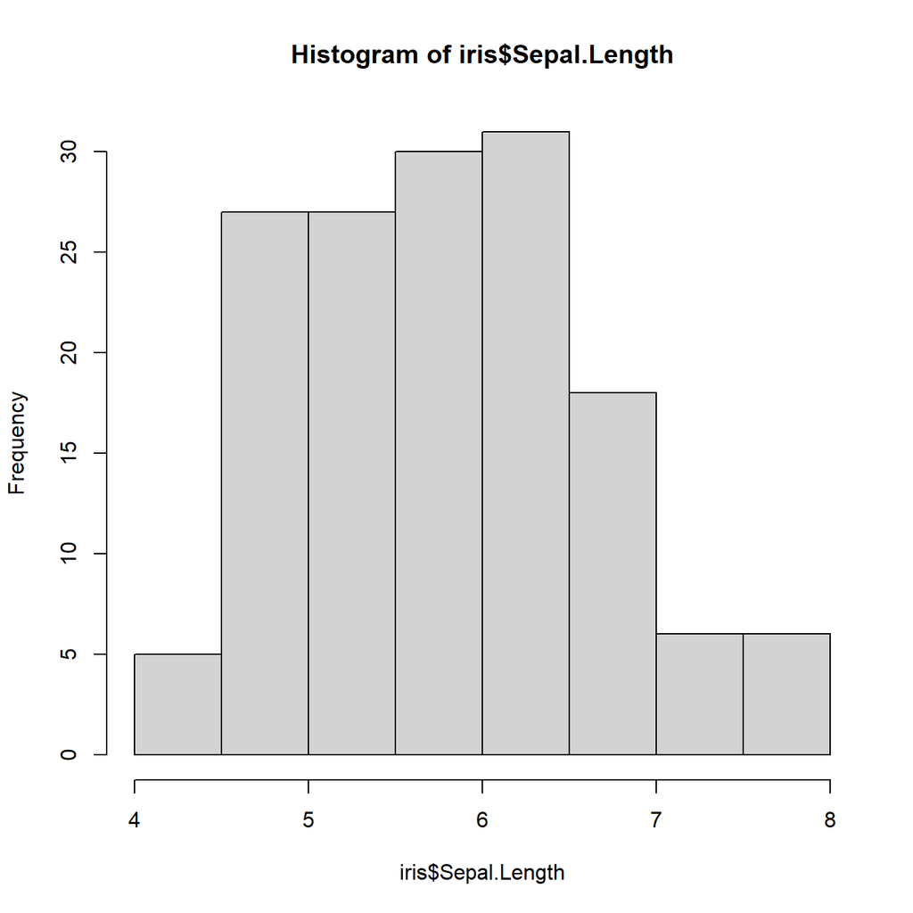

```r
# An example of creating a basic histogram of the iris sepal lengths

hist(iris$Sepal.Length)
```

I can also specify the breaks for my histogram using the `breaks =` argument

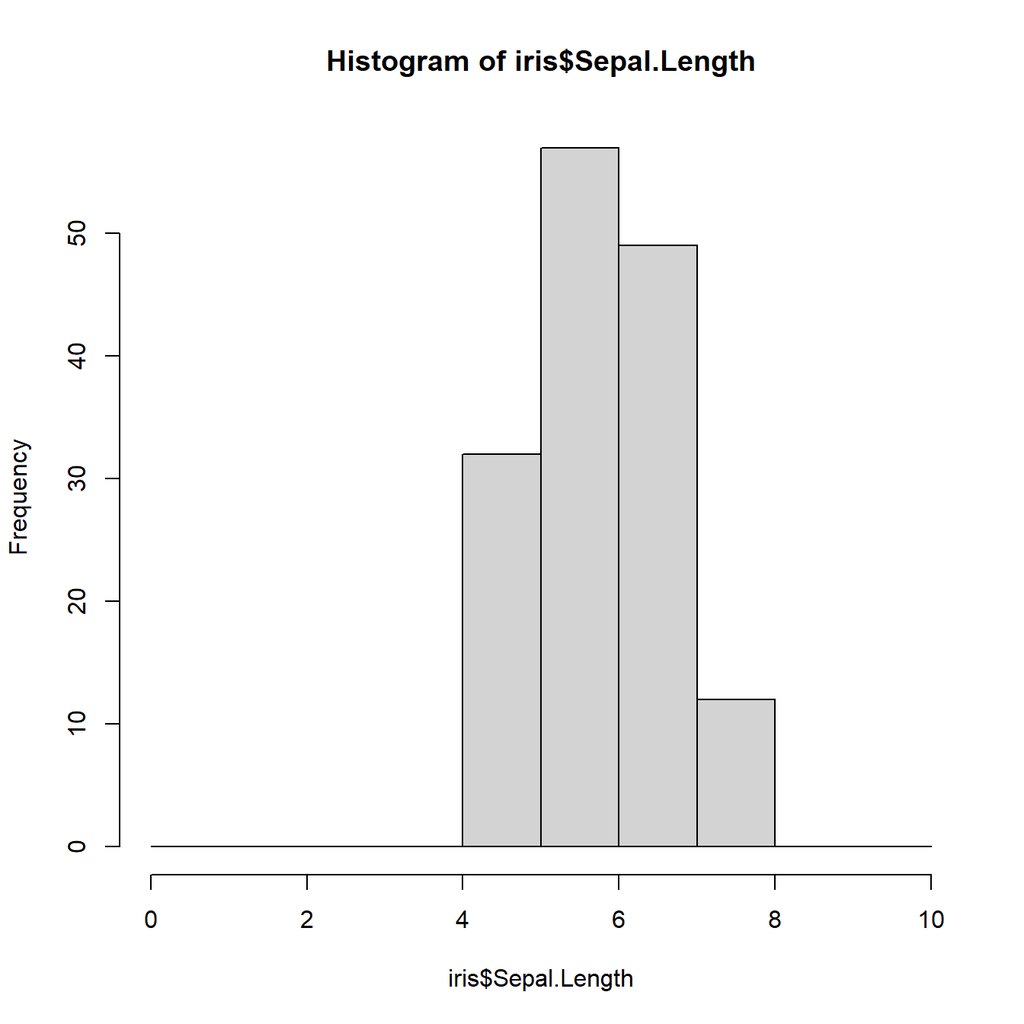

```r
# Here is an example of me specifying the breaks

hist(iris$Sepal.Length, breaks = 0:10)
```